# Figure 4

John Favate

2022-07-14 10:58:08

```r
# Prevent printing of warnings and such in the HTML
knitr::opts_chunk$set(warning = FALSE, message = FALSE, fig.align = "center")
```

```r
library(tidyverse)
library(patchwork)
library(ggpubr)
library(scales)
library(broom)
```

```r
mut.levels <- read_csv("../../data_frames/all_data.csv") %>%
  filter(gene_type == "ECB") %>%
  select(line, mutator) %>%
  arrange(mutator, line) %>%
  unique() %>%
  pull(line)

mut.colors <- c(rep("black", 6), rep("firebrick3", 5))

kegg.results <- read_csv("../../data_frames/table_s9_kegg_results.csv") %>%
  filter(seqtype == "rna") %>%
  mutate(line = factor(line, levels = mut.levels))

pps.df <- read_csv("../../data_frames/full_pps_data.csv") %>%
  filter(seqtype == "rna") %>%
  mutate(line = factor(line, levels = mut.levels))

all.data <- read_csv("../../data_frames/all_data.csv")
```

Remove some odd characters in PPS scores.

```r
pps.df$common_name <- gsub("<i>N<\\/i>", "N", pps.df$common_name) %>%
  gsub("<i>O<\\/i>", "O", .) %>%
  gsub("(<i>E. coli<\\/i>)", "", .) %>%
  gsub("\\(\\)", "", .)
```

### Panel A

```r
occurs.in.all <- kegg.results %>%
  group_by(description) %>%
  tally() %>%
  ungroup() %>%
  filter(n == 11) %>%
  pull(description)

top10 <- kegg.results %>%
  filter(qvalues <= .05 & description %in% occurs.in.all) %>%
  group_by(description) %>%
  summarise(n = n(),
            mean_e = mean(enrichmentscore, na.rm = TRUE)) %>%
  ungroup() %>%
  arrange(desc(n)) %>%
  slice(1:10) %>%
  arrange(mean_e) %>%
  pull(description)
```

These are the genes responsible for the categories.

```r
responsible.genes <- kegg.results %>%
  filter(description %in% top10 &
           description %in% occurs.in.all) %>%
  mutate(
    description = factor(description, levels = rev(top10)),
    cuts = cut(
      qvalues,
      c(1, .05, .01, .001, .0001,-Inf),
      labels = c("****", "***", "**", "*", "")
    ),
  ) %>%
  select(description, core_enrichment) %>%
  distinct() %>%
  split(.$description) %>%
  map(function(x){
    x %>%
      pull(core_enrichment) %>%
      str_split("/") %>%
      unlist() %>%
      unique()

  })
```

Some of these categories are highly redundant, I'm going to attempt to remove the redundancy

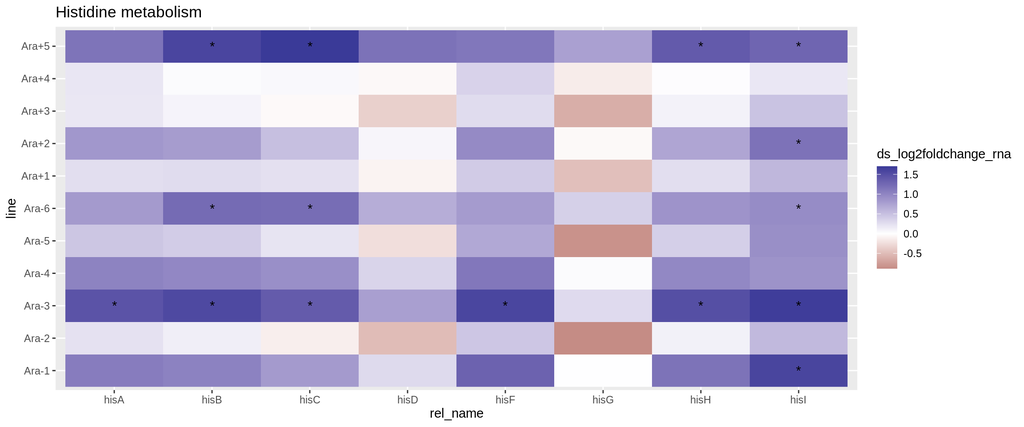

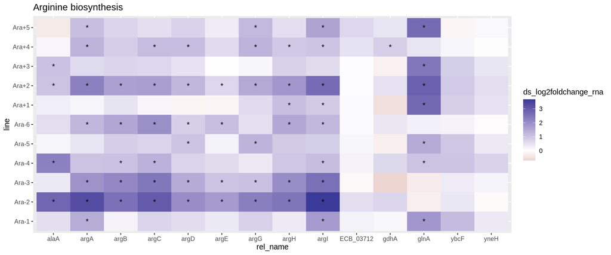

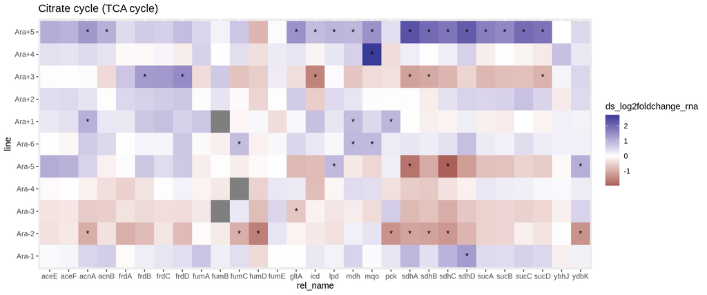

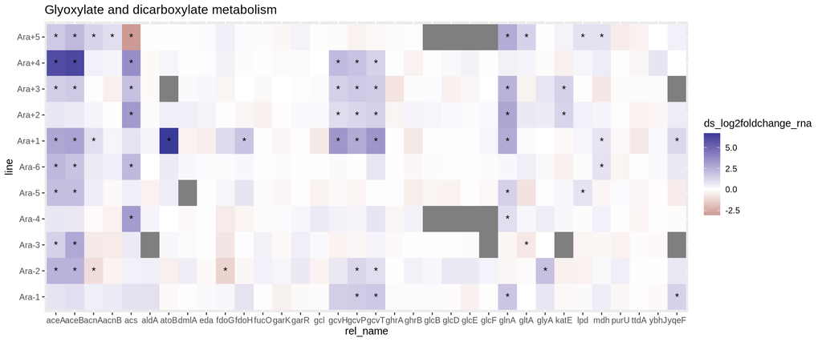

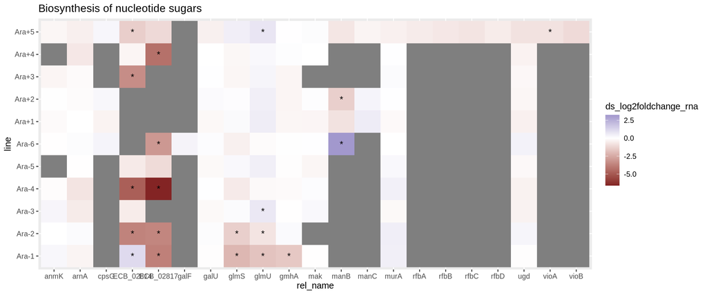

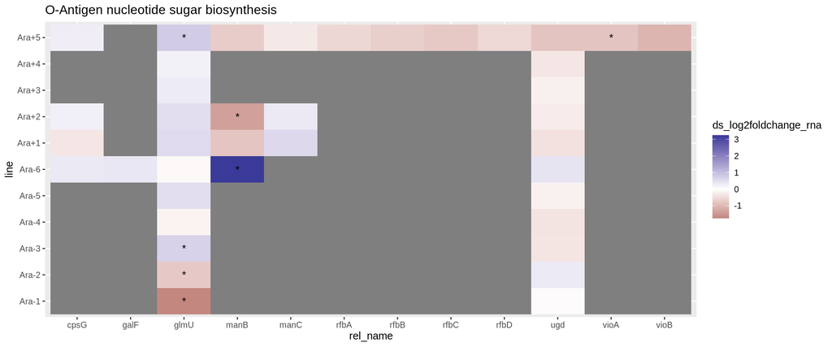

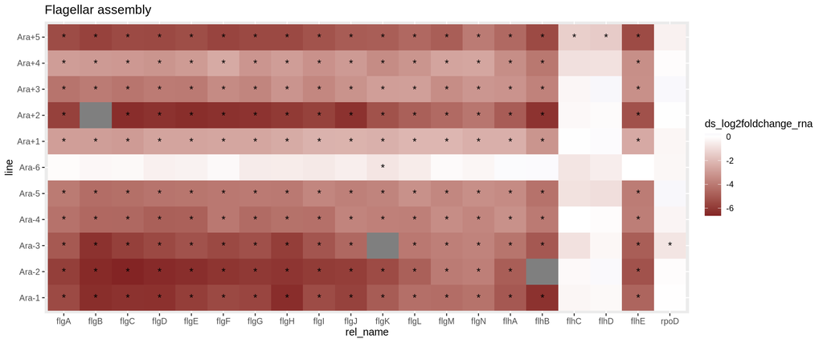

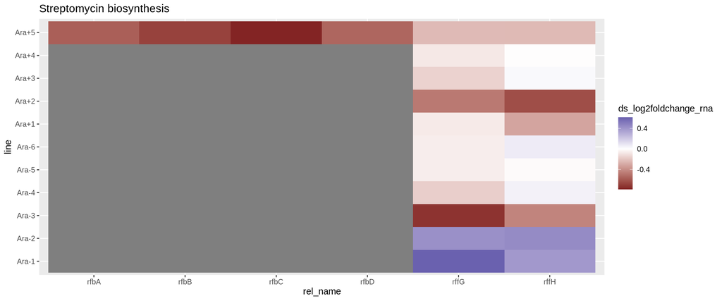

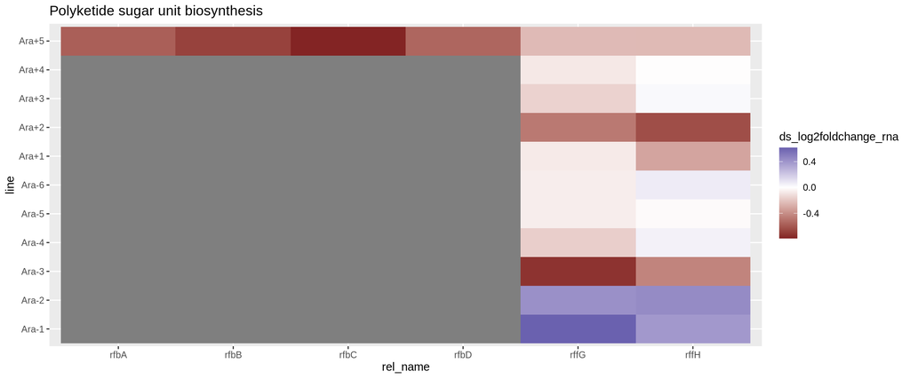

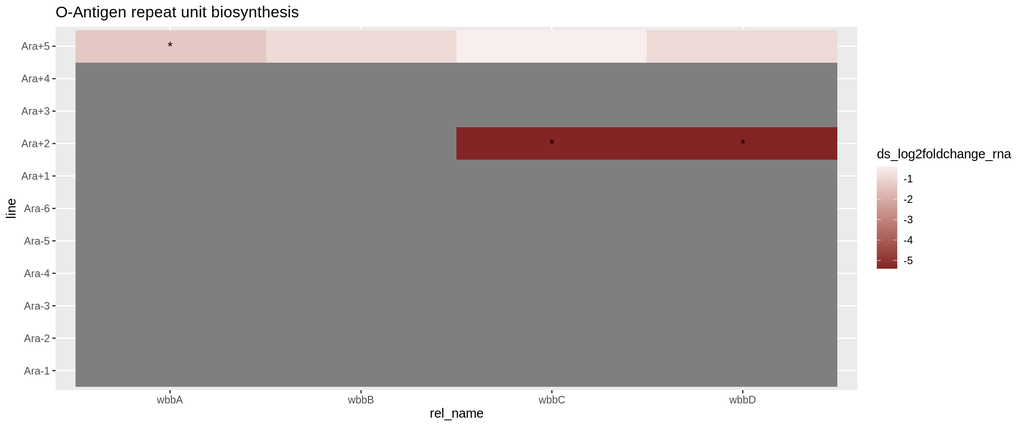

```r
lapply(names(responsible.genes), function(x){
  df <- all.data %>%
    filter(target_id %in% responsible.genes[[x]])

  p <- df %>%
    mutate(starts = ifelse(ds_padj_rna <= .01, "*", "")) %>%
    ggplot(., aes(rel_name, line, fill = ds_log2foldchange_rna, label = starts))+
    geom_raster()+
    geom_text()+
    scale_fill_gradient2()+
    labs(title = x)

  return(p)
})
```

```r
redundant <- c("O-Antigen nucleotide sugar biosynthesis", "Streptomycin biosynthesis", "Polyketide sugar unit biosynthesis")

top10.filtered <- kegg.results %>%
  filter(qvalues <= .05 & description %in% occurs.in.all & !(description %in% redundant)) %>%
  group_by(description) %>%
  summarise(n = n(),
            mean_e = mean(enrichmentscore, na.rm = TRUE)) %>%
  ungroup() %>%
  arrange(desc(n)) %>%
  slice(1:10) %>%
  arrange(mean_e) %>%
  pull(description)

top10.filtered
```

```
##  [1] "O-Antigen repeat unit biosynthesis"
##  [2] "Biosynthesis of siderophore group nonribosomal peptides"
##  [3] "Flagellar assembly"
##  [4] "Bacterial secretion system"
##  [5] "Biosynthesis of nucleotide sugars"
##  [6] "Alanine, aspartate and glutamate metabolism"
##  [7] "Glyoxylate and dicarboxylate metabolism"
##  [8] "Citrate cycle (TCA cycle)"
##  [9] "Arginine biosynthesis"
## [10] "Histidine metabolism"
```

A heatmap showing those categories

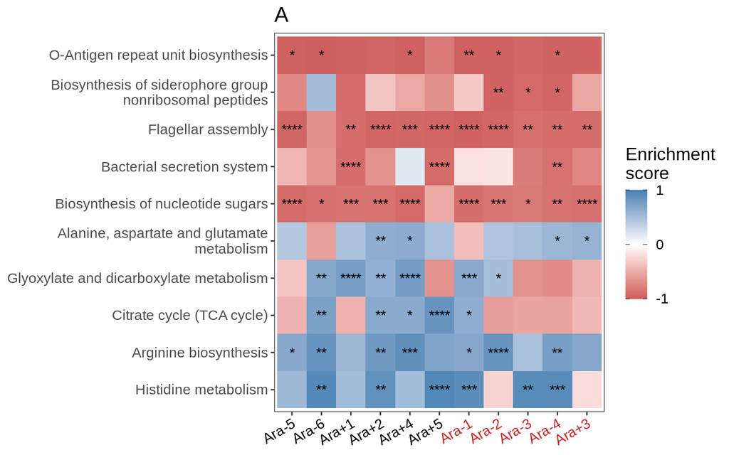

```r
adf <- kegg.results %>%
  filter(description %in% top10.filtered &
           description %in% occurs.in.all) %>%
  mutate(
    description = factor(description, levels = rev(top10.filtered)),
    cuts = cut(
      qvalues,
      c(1, .05, .01, .001, .0001,-Inf),
      labels = c("****", "***", "**", "*", "")
    ),
  ) %>%
  select(line, description, enrichmentscore, cuts)

pa <- adf %>%
  ggplot(., aes(line, description, fill = enrichmentscore, label = cuts)) +
  geom_raster() +
  theme_bw() +
  theme(
    text = element_text(size = 14),
    legend.position = "right",
    axis.text.x = element_text(color = mut.colors, angle = 30, hjust = 1),
    panel.grid = element_blank()
  ) +
  labs(x = NULL, y = NULL, title = "A") +
  scale_fill_gradientn(colors = c("indianred", "white", "steelblue"),
                       na.value = "grey30",
                       name = "Enrichment\nscore",
                       breaks = c(-1, 0, 1),
                       limits = c(-1, 1),
                       guide = guide_colorbar(ticks.colour = "black")) +
  geom_text()+
  scale_y_discrete(labels = label_wrap(width = 40))

pa
```

The new responsible genes

```r
res.genes <- kegg.results %>%
  filter(description %in% top10.filtered &
           description %in% occurs.in.all) %>%
  mutate(
    description = factor(description, levels = rev(top10)),
    cuts = cut(
      qvalues,
      c(1, .05, .01, .001, .0001,-Inf),
      labels = c("****", "***", "**", "*", "")
    ),
  ) %>%
  select(description, core_enrichment) %>%
  distinct() %>%
  split(.$description) %>%
  map(function(x){
    x %>%
      pull(core_enrichment) %>%
      str_split("/") %>%
      unlist() %>%
      unique()

  })
```

```r
lapply(names(res.genes), function(x){
  all.data %>%
    filter(target_id %in% res.genes[[x]]) %>%
    mutate(cat = x) %>%
    select(cat, target_id, rel_name, k12_name, starts_with("k12"), starts_with("rel")) %>%
    distinct()
})
```

```
## [[1]]
## # A tibble: 8 × 14
##   cat    target_id rel_name k12_name k12_accession_1 k12_accession_2 k12_product
##   <chr>  <chr>     <chr>    <chr>    <chr>           <chr>           <chr>
## 1 Histi… ECB_01921 hisG     hisG     b2019           ECK2014         "ATP phosp…
## 2 Histi… ECB_01922 hisD     hisD     b2020           ECK2015         "histidina…
## 3 Histi… ECB_01923 hisC     hisC     b2021           ECK2016         "histidino…
## 4 Histi… ECB_01924 hisB     hisB     b2022           ECK2017         "imidazole…
## 5 Histi… ECB_01925 hisH     hisH     b2023           ECK2018         "imidazole…
## 6 Histi… ECB_01926 hisA     hisA     b2024           ECK2019         "PRIBFAICA…
## 7 Histi… ECB_01927 hisF     hisF     b2025           ECK2020         "imidazole…
## 8 Histi… ECB_01928 hisI     hisI     b2026           ECK2021         "putative …
## # … with 7 more variables: k12_pathways <chr>, k12_reactions <chr>,
## #   k12_url <chr>, rel_product <chr>, rel_pathways <chr>, rel_reactions <chr>,
## #   rel_url <chr>
##
## [[2]]
## # A tibble: 14 × 14
##    cat   target_id rel_name k12_name k12_accession_1 k12_accession_2 k12_product
##    <chr> <chr>     <chr>    <chr>    <chr>           <chr>           <chr>
##  1 Argi… ECB_00471 ybcF     ybcF     b0521           ECK0514         putative c…
##  2 Argi… ECB_01481 yneH     glsB     b1524           ECK1517         glutaminas…
##  3 Argi… ECB_01730 gdhA     gdhA     b1761           ECK1759         glutamate …
##  4 Argi… ECB_02215 alaA     alaA     b2290           ECK2284         glutamate&…
##  5 Argi… ECB_02666 argA     argA     b2818           ECK2814         N-acetylgl…
##  6 Argi… ECB_03038 argG     argG     b3172           ECK3161         argininosu…
##  7 Argi… ECB_03210 argD     argD     b3359           ECK3347         <i>N</i>-a…
##  8 Argi… ECB_03712 ECB_037… <NA>     <NA>            <NA>            <NA>
##  9 Argi… ECB_03755 glnA     glnA     b3870           ECK3863         adenylyl-[…
## 10 Argi… ECB_03842 argE     argE     b3957           ECK3948         acetylorni…
## 11 Argi… ECB_03843 argC     argC     b3958           ECK3949         N-ACETYLGL…
## 12 Argi… ECB_03844 argB     argB     b3959           ECK3950         acetylglut…
## 13 Argi… ECB_03845 argH     argH     b3960           ECK3951         ARGSUCCINL…
## 14 Argi… ECB_04120 argI     argI     b4254           ECK4247         ornithine …
## # … with 7 more variables: k12_pathways <chr>, k12_reactions <chr>,
## #   k12_url <chr>, rel_product <chr>, rel_pathways <chr>, rel_reactions <chr>,
## #   rel_url <chr>
##
## [[3]]
## # A tibble: 29 × 14
```

[output cut: 97 more lines]

```
## #   k12_name <chr>, k12_accession_1 <chr>, k12_accession_2 <chr>,
## #   k12_product <chr>, k12_pathways <chr>, k12_reactions <chr>, k12_url <chr>,
## #   rel_product <chr>, rel_pathways <chr>, rel_reactions <chr>, rel_url <chr>
##
## [[10]]
## # A tibble: 4 × 14
##   cat    target_id rel_name k12_name k12_accession_1 k12_accession_2 k12_product
##   <chr>  <chr>     <chr>    <chr>    <chr>           <chr>           <chr>
## 1 O-Ant… ECB_01936 wbbD     <NA>     <NA>            <NA>            <NA>
## 2 O-Ant… ECB_01937 wbbC     wbbK     b2032           ECK2026         putative g…
## 3 O-Ant… ECB_01939 wbbB     <NA>     <NA>            <NA>            <NA>
## 4 O-Ant… ECB_01940 wbbA     <NA>     <NA>            <NA>            <NA>
## # … with 7 more variables: k12_pathways <chr>, k12_reactions <chr>,
## #   k12_url <chr>, rel_product <chr>, rel_pathways <chr>, rel_reactions <chr>,
## #   rel_url <chr>
```

### Panel B

```r
sig.cats <- kegg.results %>%
  filter(qvalues <= .05 & description %in% occurs.in.all) %>%
  pull(description) %>%
  unique()
```

Find pairwise correlations.

```r
cors <- kegg.results %>%
  filter(description %in% sig.cats) %>%
  select(line, description, enrichmentscore) %>%
  pivot_wider(names_from = line, values_from = enrichmentscore) %>%
  select(where(is.numeric)) %>%
  cor(use = "pairwise.complete.obs") %>%
  .[upper.tri(.) == TRUE] %>%
  as_tibble()
```

Make a plot.

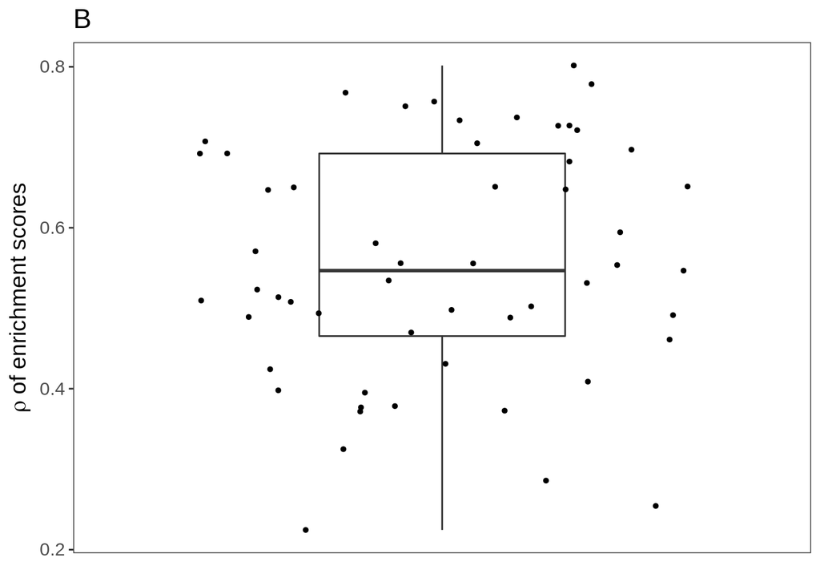

```r
pb <- cors %>%
  ggplot(., aes("", value)) +
  geom_boxplot(outlier.colour = NA, width = .4) +
  geom_jitter(size = 1)+
  labs(y = expression(paste(rho, " of enrichment scores",  sep = "")),
       x = NULL,
       title = "B") +
  theme_bw() +
  theme(text = element_text(size = 14),
        panel.grid = element_blank(),
        axis.ticks.x = element_blank())

pb
```

Range of that

```r
summary(cors$value)
```

```
##    Min. 1st Qu.  Median    Mean 3rd Qu.    Max.
##  0.2245  0.4654  0.5468  0.5553  0.6922  0.8016
```

### Panel C

The same, but for PPS scores. They're sorted in order of highest mean PPS,

```r
pps.occur <- pps.df %>%
  filter(type == "actual") %>%
  group_by(pathway, common_name) %>%
  tally() %>%
  ungroup() %>%
  filter(n == 11) %>%
  pull(common_name)

top.10.pps <- pps.df %>%
  filter(type == "actual" & common_name %in% pps.occur) %>%
  group_by(pathway, common_name) %>%
  summarise(mean_pps = mean(pps),
            varz = var(pps)) %>%
  ungroup() %>%
  arrange(desc(mean_pps), varz) %>%
  slice(1:10) %>%
  pull(common_name) %>%
  rev()
```

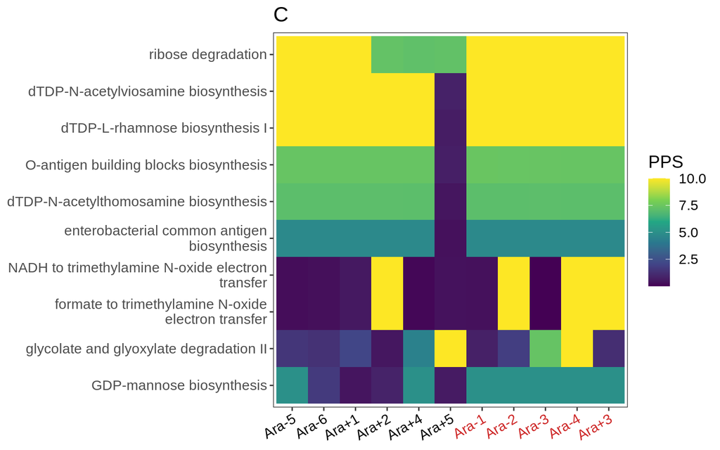

```r
pc <- pps.df %>%
  filter(common_name %in% top.10.pps & type == "actual") %>%
  mutate(common_name = factor(common_name, levels = top.10.pps)) %>%
  ggplot(., aes(line, common_name, fill = pps))+
  geom_raster()+
  scale_fill_viridis_c(option = "D", name = "PPS")+
  theme_bw() +
  theme(
    text = element_text(size = 14),
    axis.text.x = element_text(color = mut.colors, angle = 30, hjust = 1),
    panel.grid = element_blank(),
    legend.position = "right"
  ) +
  labs(x = NULL, y = NULL, title = "C")+
  scale_y_discrete(labels = label_wrap(width = 40))

pc
```

### Panel D

The same as B but for PPS

```r
pps.cors <- pps.df %>%
  filter(type == "actual") %>%
  select(line, pathway, pps) %>%
  pivot_wider(names_from = line, values_from = pps) %>%
  select(where(is.numeric)) %>%
  cor(use = "pairwise.complete.obs") %>%
  .[upper.tri(.) == TRUE] %>%
  as_tibble() %>%
  mutate(iteration = "real")
```

Now show this distribution using the randomized PPS. That is, in the analysis file, the fold-changes were randomized prior to calculating PPS, meaning 1. you'll have lower overall PPS because there are no coordinated changes and 2. the correlations among lines is lower because you've lost whatever parallel changes have occurred.

```r
exp.pps.cors <- pps.df %>%
  filter(type == "random") %>%
  split(.$iteration) %>%
  map(function(x){
    x %>%
      select(line, pathway, pps) %>%
      pivot_wider(names_from = line, values_from = pps) %>%
      column_to_rownames("pathway") %>%
      cor(use = "pairwise.complete.obs", method = "spearman") %>%
      .[upper.tri(.)] %>%
      as_tibble()
  }) %>%
  bind_rows(.id = "iteration")
```

```r
pps.bracket.df <- ks.test(pps.cors$value, exp.pps.cors$value) %>%
  tidy() %>%
  mutate(
    label = cut(
    p.value,
    c(1, .05, .01, .001, .0001, -Inf),
    labels = c("****", "***", "**", "*", "")
    ),
    xmin = "Expected",
    xmax = "Observed",
    y.position = .8)
```

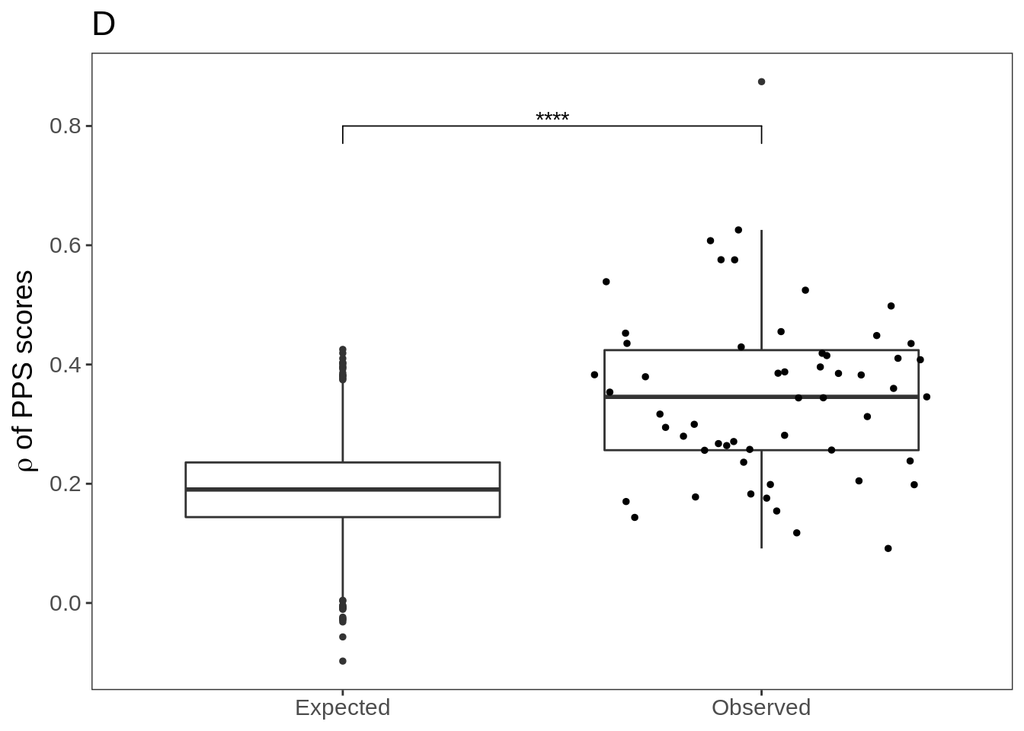

```r
# make a df for the actual points, make a column where outliers are NA
# so the boxplot is made using the full data (displaying outliers) but
# said outliers aren't double plotted by the jitter
pps1 <- as_tibble(pps.cors) %>%
  mutate(points = case_when(value - quantile(value)[4] > 1.5*IQR(value) ~ NA_real_,
                                  quantile(value)[2] - value > 1.5*IQR(value) ~ NA_real_,
                                  TRUE ~ value))

# the fake cors should have no points to plot, there'd be too many
# this will plot outliers as normal
pps2 <- exp.pps.cors %>%
  mutate(points = NA)


pd <- bind_rows("Observed" = pps1, "Expected" = pps2, .id = "type") %>%
  ggplot(., aes(type, value))+
  geom_boxplot(outlier.size = 1)+
  geom_jitter(inherit.aes = FALSE, aes(type, points), height = 0, size = 1)+
  labs(y = expression(paste(rho, " of PPS scores",  sep = "")),
       x = NULL,
       title = "D")+
  theme_bw()+
  theme(text = element_text(size = 14),
        panel.grid = element_blank())+
  geom_bracket(data = pps.bracket.df, vjust = .5)+
  scale_y_continuous(breaks = seq(-.2, .8, .2))

pd
```

Mean and SD of PPS scores to find unaltered pathways

```r
pps.df %>%
  filter(type == "actual") %>%
  group_by(seqtype, pathway, common_name) %>%
  summarise(mean_pps = mean(pps),
            sd_pps = sd(pps)) %>%
  ungroup() %>%
  arrange(seqtype, mean_pps, sd_pps)
```

| seqtype | pathway | common_name | mean_pps | sd_pps |
| --- | --- | --- | --- | --- |
| rna | PWY-6019 | pseudouridine degradation | 0.1191697 | 0.06375163 |
| rna | GLUT-REDOX-PWY | glutathione redox reactions II | 0.1232313 | 0.13933327 |
| rna | PWY0-1535 | D-serine degradation | 0.1252767 | 0.06631869 |
| rna | PWY0-43 | conversion of succinate to propionate | 0.1295504 | 0.08824964 |
| rna | PWY-5783 | octaprenyl diphosphate biosynthesis | 0.1300347 | 0.11308976 |
| rna | PWY-7343 | UDP-glucose biosynthesis | 0.1449031 | 0.08550156 |
| rna | MANNCAT-PWY | D-mannose degradation | 0.1505935 | 0.13469843 |
| rna | MENAQUINONESYN-PWY | menaquinol-8 biosynthesis | 0.1622286 | 0.13115933 |
| rna | XYLCAT-PWY | xylose degradation I | 0.1659910 | 0.10457851 |
| rna | PWY-5669 | phosphatidylethanolamine biosynthesis I | 0.1789786 | 0.11392021 |

[output cut: 348 more lines]

### Final figure

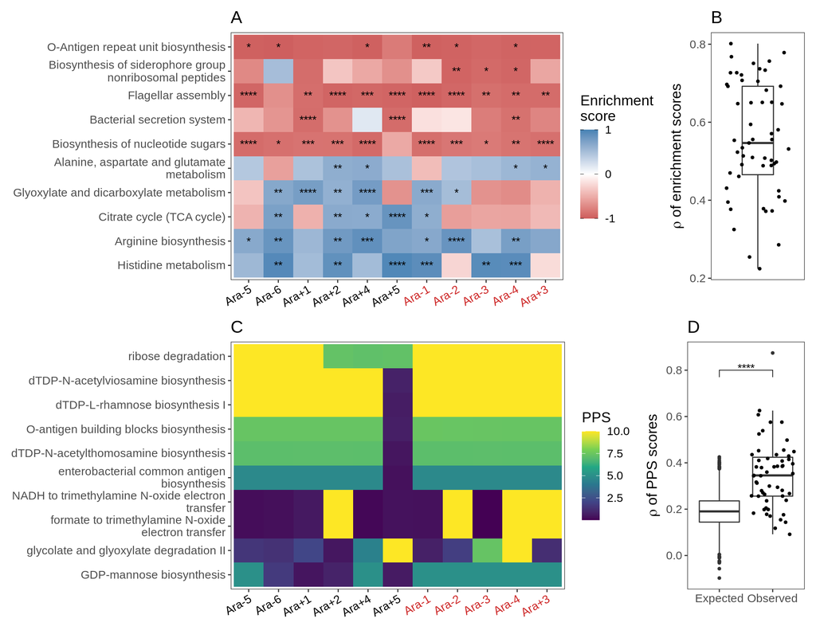

```r
top <- (pa | pb) + plot_layout(widths = c(.78, .22))

bottom <- (pc | pd) + plot_layout(widths = c(.74, .26))

(ff <- top / bottom)
```

Save it in various formats

```r
ggsave(ff, filename = "../../figures/fig_4.png", width = 11, height = 8.5)

ggsave(ff, filename = "../../figures/fig_4.pdf", device = cairo_pdf, width = 11, height = 8.5)

write_rds(ff, "../../figures/fig_4.rds")
```